# Load Data

```python
import pandas as pd

df_User_Interactions = pd.read_csv('https://storage.googleapis.com/datalynn-datasets/interview-challenge/technology/Meta_Facebook_User_Experience/UserInteractions.csv')
df_User_Feedback = pd.read_csv('https://storage.googleapis.com/datalynn-datasets/interview-challenge/technology/Meta_Facebook_User_Experience/UserFeedback.csv')
print(df_User_Feedback.head())
print(df_User_Interactions.head())
```

```
   user_id feature_name        feedback_date  feedback_score  \
0        1    Feature_D  2023-09-11 17:21:00             NaN
1        2    Feature_E  2023-08-10 17:21:00             5.0
2        3    Feature_C  2023-01-31 17:21:00             NaN
3        4    Feature_E  2023-07-10 17:21:00             1.0
4        5    Feature_E  2023-08-14 17:21:00             2.0

        feedback_text
0  Needs improvement.
1    Amazing feature!
2      Too confusing.
3  Needs improvement.
4  Needs improvement.
   user_id feature_name     interaction_date  interaction_time drop_point
0        1    Feature_D  2023-10-02 17:21:00               211   Point_D1
1        2    Feature_E  2023-08-26 17:21:00              1088   Point_E3
2        3    Feature_C  2023-03-01 17:21:00              1278   Point_C1
3        4    Feature_E  2023-07-15 17:21:00              2037   Point_E3
4        5    Feature_E  2023-08-31 17:21:00              3414   Point_E1
```

```python
dfi = df_User_Interactions.copy()
dff = df_User_Feedback.copy()
```

## Question 1

**Scenario:** There have been complaints from the product team that some feedback scores are missing, and certain interaction times seem unusually high, potentially due to logging errors.

**Task:** Identify and handle missing values in the `feedback_score` column from the `User_Feedback` table. Additionally, detect and treat outliers in the `interaction_time` column of the `User_Interactions` table.

Handling Missing Values in feedback_score:

```python
import pandas as pd

# Check missing values
missing_values = dff['feedback_score'].isnull().sum()
print(missing_values)

# Impute with median
if missing_values > 0:
    median_score = dff['feedback_score'].median()
    dff['feedback_score'].fillna(median_score, inplace=True)

# Save the updated dataframe
dff.to_csv('Updated_User_Feedback.csv', index=False)# Check missing values
missing_values = dff['feedback_score'].isnull().sum()

# Impute with median
if missing_values > 0:
    median_score = dff['feedback_score'].median()
    dff['feedback_score'].fillna(median_score, inplace=True)

# check missing values again
print(dff['feedback_score'].isnull().sum())
```

```
249
0
```

**Detecting and Treating Outliers in interaction_time:**

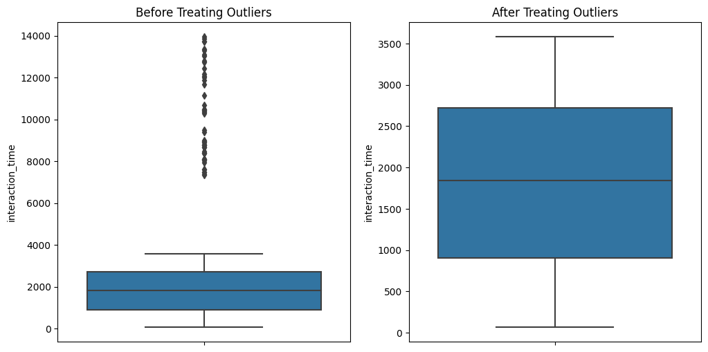

```python
import pandas as pd
import numpy as np
import matplotlib.pyplot as plt
import seaborn as sns

# Calculate IQR for interaction_time
Q1 = dfi['interaction_time'].quantile(0.25)
Q3 = dfi['interaction_time'].quantile(0.75)
IQR = Q3 - Q1

# Define bounds
lower_bound = Q1 - 1.5 * IQR
upper_bound = Q3 + 1.5 * IQR

# Plot before treating outliers
plt.figure(figsize=(12, 6))
plt.subplot(1, 2, 1)
sns.boxplot(y=dfi['interaction_time'])
plt.title('Before Treating Outliers')

# Cap outliers at the 1st and 99th percentiles
p1 = dfi['interaction_time'].quantile(0.25)
p99 = dfi['interaction_time'].quantile(0.75)

dfi['interaction_time'] = np.where(dfi['interaction_time'] < lower_bound, p1, dfi['interaction_time'])
dfi['interaction_time'] = np.where(dfi['interaction_time'] > upper_bound, p99, dfi['interaction_time'])

# Plot after treating outliers
plt.subplot(1, 2, 2)
sns.boxplot(y=dfi['interaction_time'])
plt.title('After Treating Outliers')
```

## Question 2

**Scenario:** The management wants to understand which features have the least favorable feedback and also see which features have the highest interaction times, possibly indicating user struggles.

**Task:** Using SQL, join `User_Feedback` and `User_Interactions` tables on `user_id` and `feature_name`. Find the feature with the lowest average feedback score and the feature with the third-highest average interaction time.

```python
# Install the necessary packages:
!pip install ipython-sql
# Load the SQL extension:
%load_ext sql
# Connect to SQLite:
%sql sqlite:///example.db
```

```
     ━━━━━━━━━━━━━━━━━━━━━━━━━━━━━━━━━━━━━━━━ 1.6/1.6 MB 17.8 MB/s eta 0:00:00
```

```python
import sqlite3
# Connect to the SQLite database
conn = sqlite3.connect('example.db')
df_User_Feedback.to_sql('UserFeedback', conn, if_exists='replace', index=False)
df_User_Interactions.to_sql('UserInteraction', conn, if_exists='replace', index=False)
```

```
1005
```

SQL Query to find the feature with the lowest average feedback score

```python
%%sql
-- Joining the tables and calculating average values for feedback_score and interaction_time
WITH FeatureAverages AS (
    SELECT
        f.feature_name,
        AVG(f.feedback_score) AS avg_feedback,
        AVG(i.interaction_time) AS avg_interaction_time
    FROM
        UserFeedback f
    JOIN
        UserInteraction i ON f.user_id = i.user_id AND f.feature_name = i.feature_name
    GROUP BY
        f.feature_name
)

-- Finding the feature with the lowest average feedback score
SELECT
    feature_name,
    avg_feedback
FROM
    FeatureAverages
ORDER BY
    avg_feedback ASC
LIMIT 1;
```

```
 * sqlite:///example.db
Done.
```

| feature_name | avg_feedback |
| --- | --- |
| Feature_C | 2.9034482758620688 |

SQL query to find the feature with the third-highest average interaction time

```python
%%sql
-- Joining the tables and calculating average values for feedback_score and interaction_time, same as above
WITH FeatureAverages AS (
    SELECT
        f.feature_name,
        AVG(f.feedback_score) AS avg_feedback,
        AVG(i.interaction_time) AS avg_interaction_time
    FROM
        UserFeedback f
    JOIN
        UserInteraction i ON f.user_id = i.user_id AND f.feature_name = i.feature_name
    GROUP BY
        f.feature_name
)
-- Finding the feature with the third-highest average interaction time
SELECT
    feature_name,
    avg_interaction_time
FROM
    FeatureAverages
ORDER BY
    avg_interaction_time DESC
LIMIT 1 OFFSET 2; -- Using OFFSET to skip the first two rows and get the third one
```

```
 * sqlite:///example.db
Done.
```

| feature_name | avg_interaction_time |
| --- | --- |
| Feature_C | 2112.942105263158 |

## Question 3

**Scenario:** The product team hypothesizes that user interactions with a certain feature have been dropping over time due to the negative feedback received.

**Task:** Based on the `User_Feedback` table, calculate the probability that on a given day, a user gives a feedback score below 3 AND interacts with the feature for more than 300 seconds. Implement this calculation programmatically to validate the product team's hypothesis.

The probability that both events $A$ and $B$ occur is given by: $$P(A∩B) = P(A) × P(B|A)$$ where:

- $P(A)$ is the probability that a user gives a feedback score below 3.
- $P(B|A)$ is the probability that, given a user gave a feedback score below 3, they interact with the feature for more than 300 seconds.

```python
# Calculate P(A)
p_a = len(dff[dff['feedback_score'] < 3]) / len(dff)

# Filter users who gave feedback < 3
users_low_feedback = dff[dff['feedback_score'] < 3]['user_id']

# Filter interactions for those users
filtered_interactions = dfi[dfi['user_id'].isin(users_low_feedback)]

# Calculate P(B|A)
p_b_given_a = len(filtered_interactions[filtered_interactions['interaction_time'] > 300]) / len(filtered_interactions)

# Calculate P(A ∩ B)
p_a_and_b = p_a * p_b_given_a

print(f"Probability that on a given day, a user gives a feedback score below 3 AND interacts with the feature for more than 300 seconds: {p_a_and_b:.4f}")
```

```
Probability that on a given day, a user gives a feedback score below 3 AND interacts with the feature for more than 300 seconds: 0.2781
```

While the probability of 27.81% seems significant, validating the hypothesis requires a comprehensive look at data from different angles and over time. If over time this probability has been growing, it might be a good sign that negative feedback is indeed affecting user interactions.

## Question 4

**Scenario:** Post your analysis, the product team decides to introduce a revised version of the least favorable feature. They plan to run an A/B test to compare the old and new versions.

**Task:** Design an A/B test strategy to measure the success of the new feature. Considering your findings from the above questions, what metrics would you track and what insights would you look to derive to determine the success of the new feature?

**A/B Test Strategy**

1. Objective: Determine if the revised feature improves user satisfaction and engagement compared to the old version.
2. Randomized Groups:
- Control Group (A): Users who will interact with the old version of the feature.
- Treatment Group (B): Users who will interact with the revised version of the feature.
3. Sampling Strategy: Ensure users are randomly assigned to groups, maintaining a balance of demographics and behavior types (e.g., new vs. returning users) to prevent any bias.
4. Metrics to Track:
- Feedback Score: Average feedback score for the feature. Given that the previous analysis indicated issues with the feature's feedback, it's crucial to monitor if the revised feature leads to higher average feedback scores.
- Interaction Time: Average interaction time with the feature. A significant reduction might indicate users are finding the feature more intuitive and less problematic.
5. Criteria for Success:
- Use statistical tests (e.g., t-test) to compare the primary metrics between the control and treatment groups. The revised feature should show a statistically significant improvement in the primary metrics (higher feedback scores, reduced interaction time).